# BIOS 545 Spring 2015 Week 5 Lab 1: Graphics Part 1

Pittard wsp@emory.edu ***

## Base Graphics

PRACTICE 1.0) DRAWING GRAPHICS USING GRAPHICS “PRIMITIVES” IS EASY.

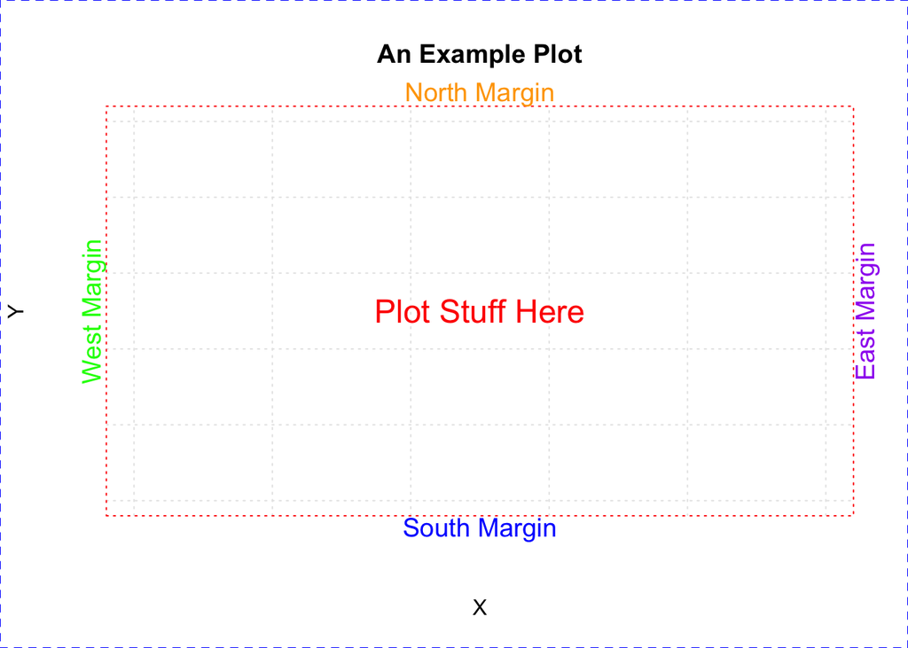

```r
plot(0:10, 0:10, type="n", xlab="X", ylab="Y", axes=FALSE)

abline(h=seq(0,10,2),lty=3,col="gray90")

abline(v=seq(0,10,2),lty=3,col="gray90")

text(5,5, "Plot Stuff Here", col="red", cex=1.5)

box("plot", col="red", lty = "dotted")

box("inner", col="blue", lty = "dashed")

mtext("South Margin",1,cex=1.2,col="blue")

mtext("West Margin",2,cex=1.2,col="green")

mtext("North Margin",3,cex=1.2,col="orange")

mtext("East Margin",4,cex=1.2,col="purple")

title("An Example Plot")
```

***

PRACTICE 1.1) WE CAN CREATE PLOTS SIDE-BY-SIDE (TWO PANELS ON A SINGLE PLOT WINDOW)

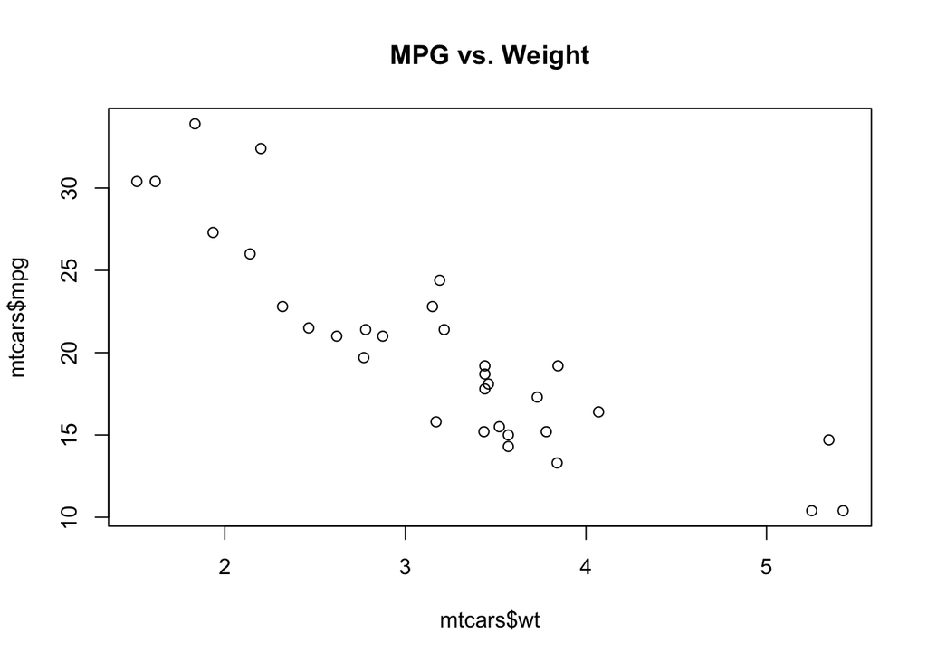

```r
plot(mtcars$wt, mtcars$mpg, main="MPG vs. Weight")
```

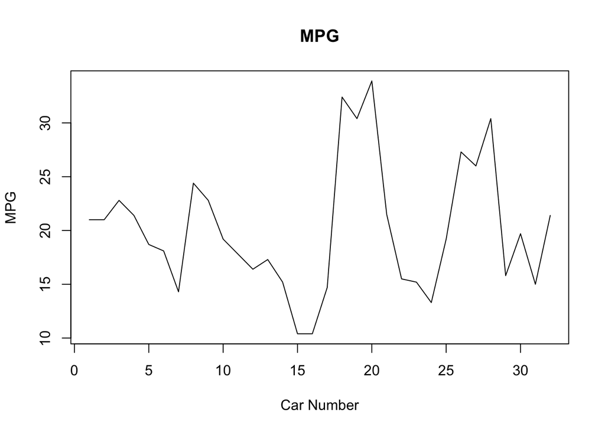

```r
plot(mtcars$mpg, main="MPG", type="l",xlab="Car Number",ylab="MPG")
```

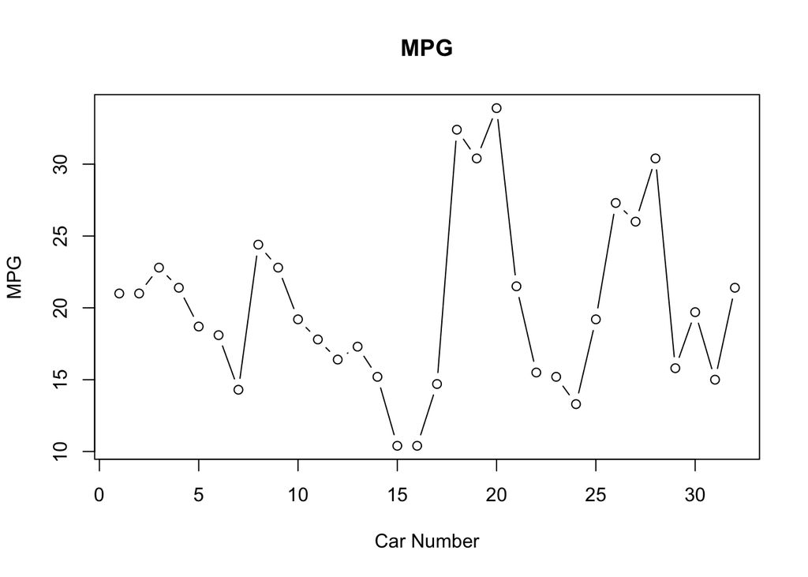

```r
plot(mtcars$mpg, main="MPG", type="b",xlab="Car Number",ylab="MPG")
```

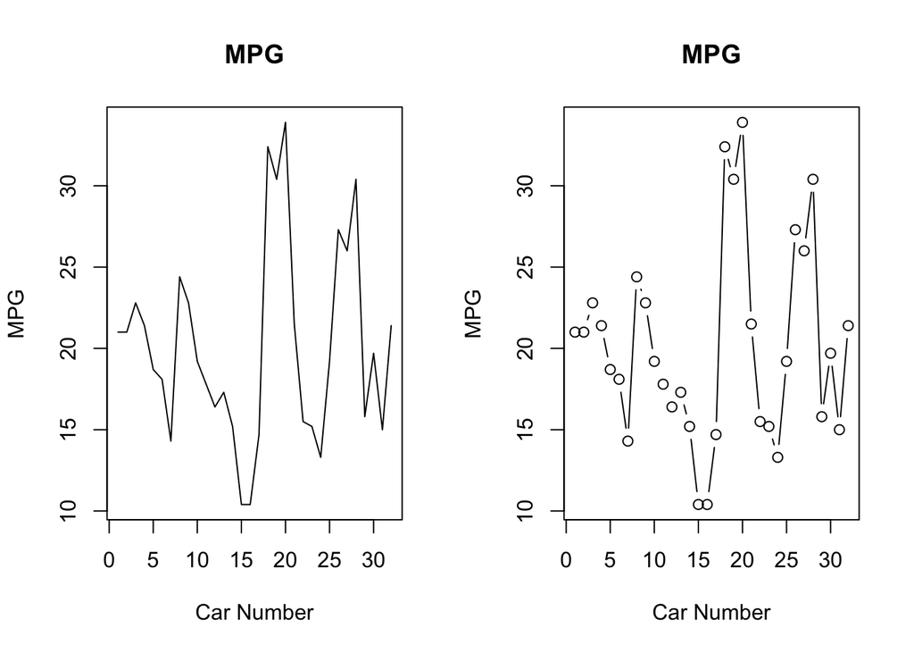

```r
par(mfrow=c(1,2)) # One row and two columns

plot(mtcars$mpg, main="MPG", type="l",xlab="Car Number",ylab="MPG")

plot(mtcars$mpg, main="MPG", type="b",xlab="Car Number",ylab="MPG")
```

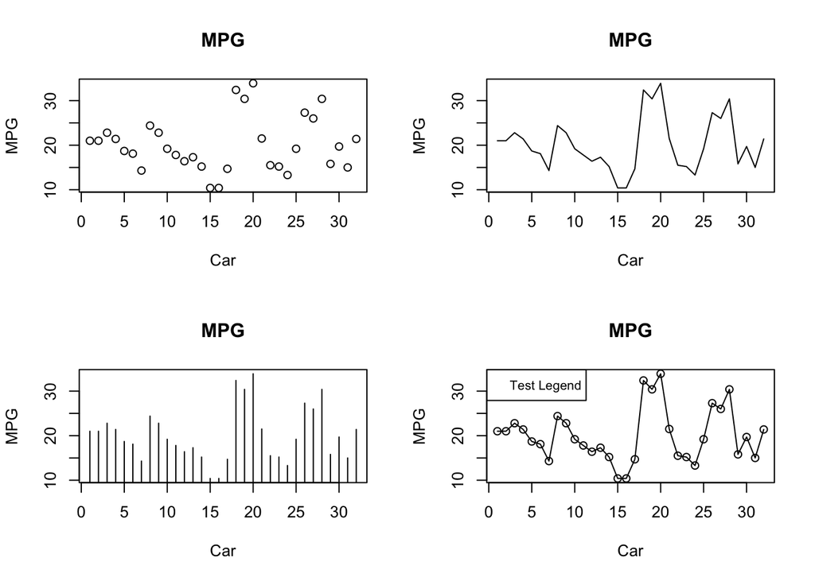

```r
par(mfrow=c(2,2))

plot(mtcars$mpg,main="MPG",xlab="Car",ylab="MPG",type="p")

plot(mtcars$mpg,main="MPG",xlab="Car",ylab="MPG",type="l")

plot(mtcars$mpg,main="MPG",xlab="Car",ylab="MPG",type="h")

plot(mtcars$mpg,main="MPG",xlab="Car",ylab="MPG",type="o")

legend("topleft",legend=c("Test Legend"),cex=0.8)
```

***

PRACTICE 1.2) WE CAN GENERATE A PLOT USING FOR LOOPS

```r
unique(mtcars$cyl)   # We have three categories so let's create 3 plots
```

```
## [1] 6 4 8
```

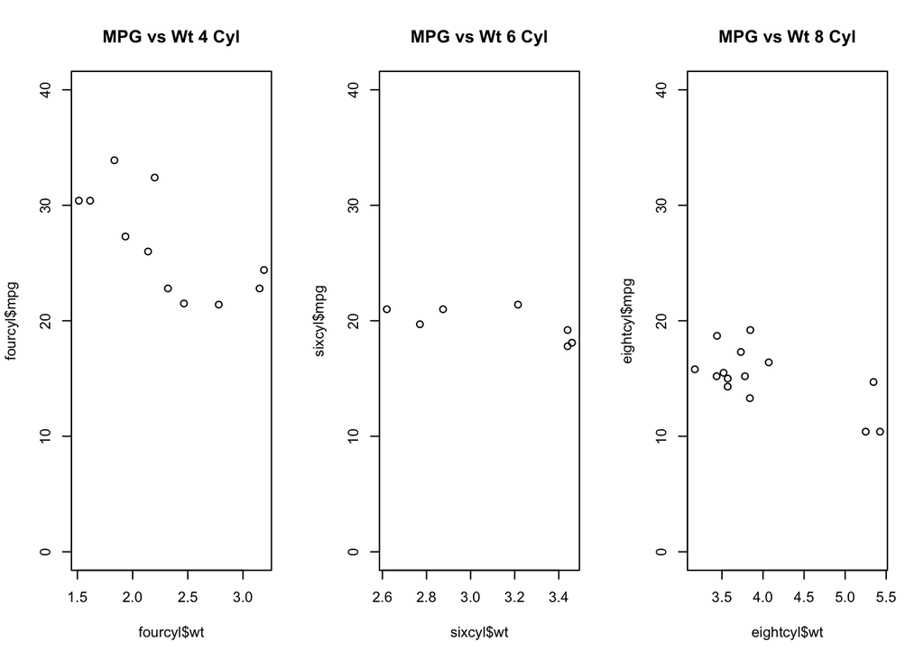

```r
par(mfrow=c(1,3))   # One row and three columns

fourcyl   <- mtcars[mtcars$cyl == 4,]
sixcyl    <- mtcars[mtcars$cyl == 6,]
eightcyl  <- mtcars[mtcars$cyl == 8,]

plot(fourcyl$wt, fourcyl$mpg, main = "MPG vs Wt 4 Cyl", ylim=c(0,40))
plot(sixcyl$wt, sixcyl$mpg, main = "MPG vs Wt 6 Cyl", ylim=c(0,40))
plot(eightcyl$wt, eightcyl$mpg, main = "MPG vs Wt 8 Cyl", ylim=c(0,40))
```

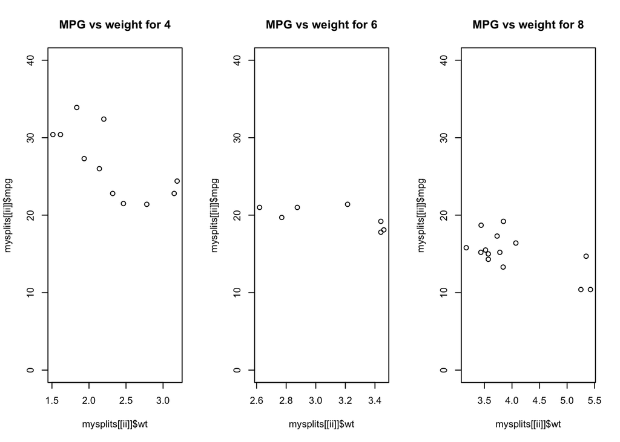

```r
par(mfrow=c(1,1)) # Reset the plot window

# Slide 28

par(mfrow=c(1,3))   # One row and three columns
mysplits <- split(mtcars, mtcars$cyl)

for (ii in 1:length(mysplits)) {
    plot(mysplits[[ii]]$wt, mysplits[[ii]]$mpg,
    ylim = c(0,40),
    main=paste("MPG vs weight for",names(mysplits[ii])))
}
```

```r
# Better yet we could make this into a function

cyl.plot <- function(df, fac, numrows=1, numcols=3) {
  par(mfrow=c(numrows,numcols))
  mysplits <- split(df,fac)
  for (ii in 1:length(mysplits)) {
    plot(mysplits[[ii]]$wt, mysplits[[ii]]$mpg,
         ylim = c(0,40),
         main=paste("MPG vs weight for",names(mysplits[ii])))
  }
}
cyl.plot(mtcars,mtcars$cyl)

par(mfrow=c(1,1))  # reset the plot device
```

[output not shown]

PRACTICE 1.3) MORE PLOTTING EXAMPLES WITH ANNOTATION

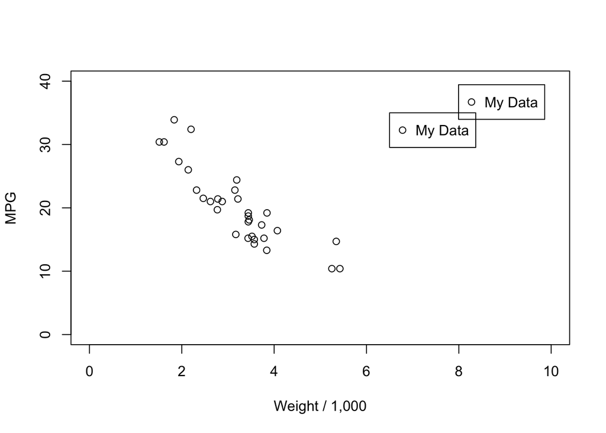

```r
plot(mtcars$wt, mtcars$mpg, xlab = "Weight / 1,000", ylab = "MPG",
     xlim = c(0,10), ylim = c(0,40))

# Slide 30

plot(mtcars$wt, mtcars$mpg, xlab = "Weight / 1,000", ylab = "MPG",
     xlim = c(0,10), ylim = c(0,40))


legend("topright", inset=0.05, "My Data", pch=1, col="black")

# Could use specific coordinates also

legend(6.5,35, inset=0.05, "My Data", pch=1, col="black")
```

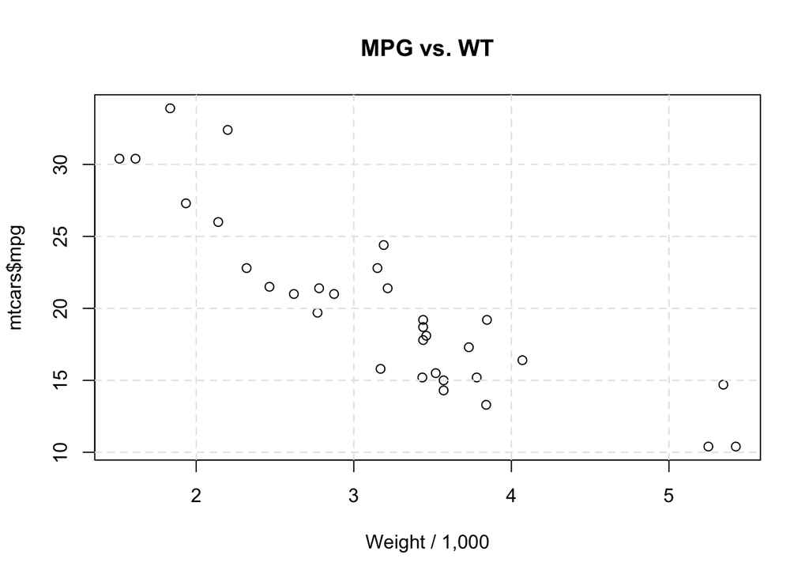

```r
# Slide 32

plot(mtcars$wt, mtcars$mpg,
               xlab = "Weight / 1,000",
               main = "MPG vs. WT")

abline(v=c(2,3,4,5),lty=2,col="gray90")

# Draws vertical dashed lines at 2,3,4,5

abline(h=c(10,15,20,25,30), lty=2, col="gray90")

# Horizontal lines at 10,15,20,25,30

# Could do:

abline(v=c(2,3,4,5),lty=2,col="gray90")

abline(h=seq(10,30,5),lty=2,col="gray90")
```

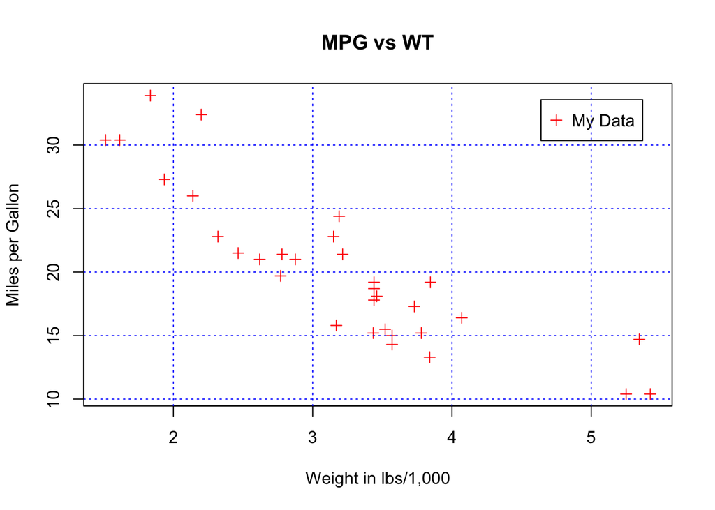

```r
# Slide 34

plot(mtcars$wt, mtcars$mpg,main="MPG vs WT", col="red",
               xlab="Weight in lbs/1,000",
               ylab="Miles per Gallon",
               pch = 3)


legend("topright", inset=0.05, "My Data", pch = 3, col="red")

grid(col="blue")
```

***

## Plot Characters

2.0) LET’S PLOT POINTS (MPG VS WT) AND USE DIFFERENT PLOT CHARACTERS BASED ON TRANSMISSION TYPE

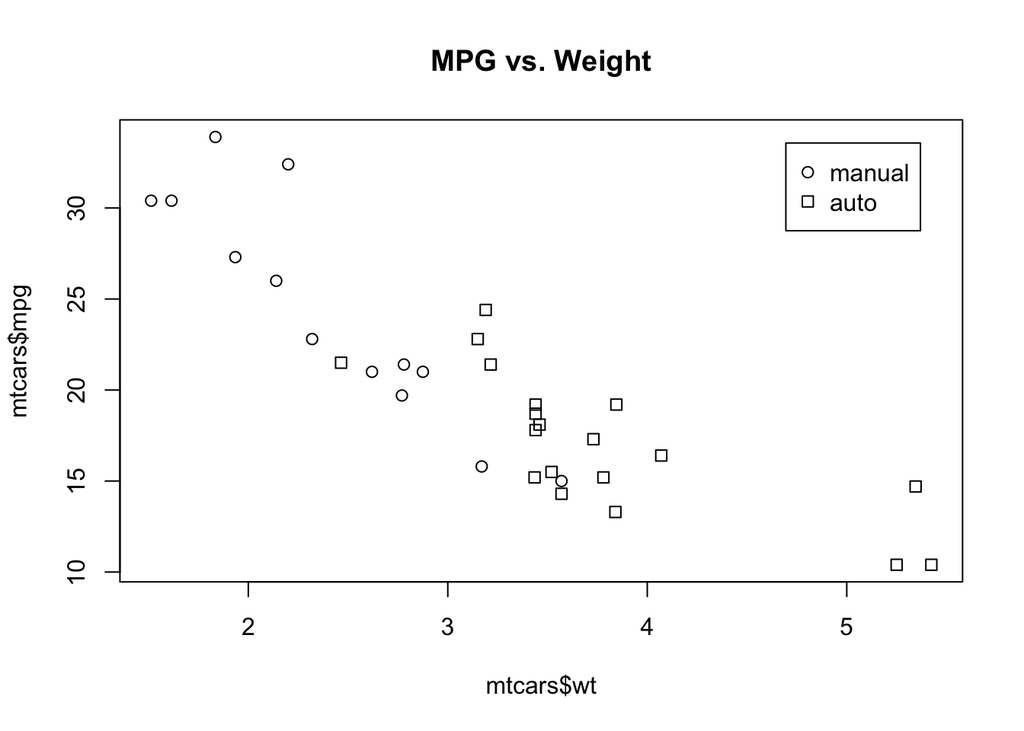

```r
# example(pch) THIS GENERATES A LOT OF OUTPUT

# Slide 36

plot(mtcars$wt, mtcars$mpg, type="n", main="MPG vs. Weight")  # A null plot

auto <- mtcars[mtcars$am == 0,]
manu <- mtcars[mtcars$am == 1,]

points(auto$wt, auto$mpg, pch = 0)
points(manu$wt, manu$mpg, pch = 1)

legend("topright", inset=0.05, c("manual","auto"),
        pch = c(1,0))
```

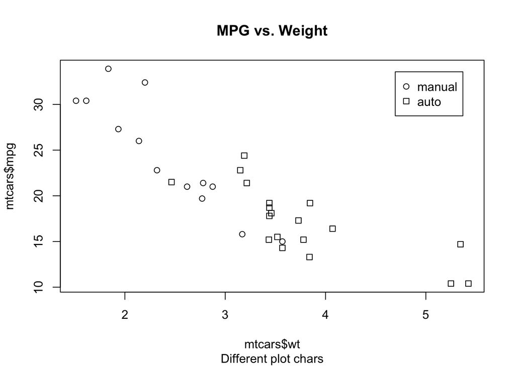

```r
# Slide 38

plot(mtcars$wt, mtcars$mpg, pch=mtcars$am,
     main="MPG vs. Weight", sub="Different plot chars")

legend("topright", inset=0.05, c("manual","auto"),
        pch = unique(mtcars$am))
```

***

## PLOT COLORS

2.1) HERE WE USE DIFFERENT COLORS TO INDICATE POINTS ABOVE AND BELOW THE MEAN WEIGHT

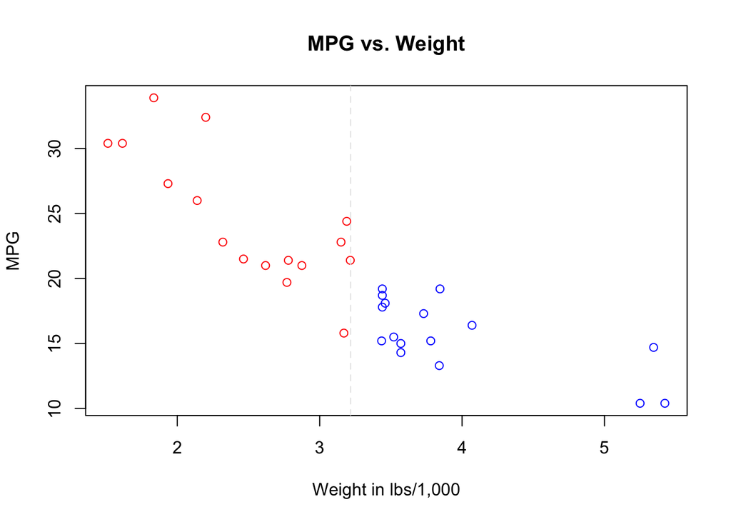

```r
plot(mtcars$wt,mtcars$mpg,type="n",xlab="Weight in lbs/1,000",
     ylab="MPG", main="MPG vs. Weight")

# Let's get records for each category

above.mean <- mtcars[mtcars$wt >= mean(mtcars$wt),]

below.mean <- mtcars[mtcars$wt < mean(mtcars$wt),]

# Use the points command to plot each group

points(below.mean$wt,below.mean$mpg,col="red")

points(above.mean$wt,above.mean$mpg,col="blue")

# Draw a vertical line where the mean(wt) is

abline(v=mean(mtcars$wt),lty=2,col="gray90")
```

***

2.2) OR WE CAN USE THE IFELSE STRUCTURE TO MAKE THIS HAPPEN MORE CONVENIENTLY. ALWAYS LOOK FOR SHORTCUTS

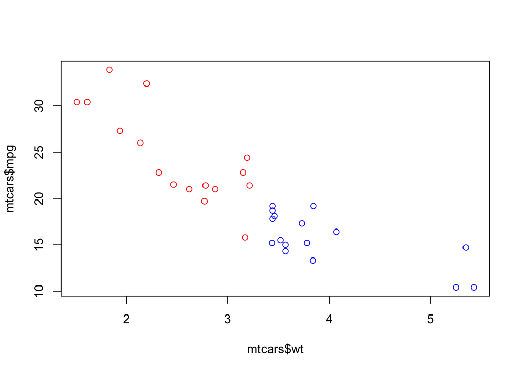

```r
colvec <- ifelse(mtcars$wt >= mean(mtcars$wt),"blue","red")

plot(mtcars$wt,mtcars$mpg,col=colvec)

# OR YOU COULD DO IT ALL IN ONE LINE THOUGH READABILITY SUFFERS

plot(mtcars$wt,mtcars$mpg,col=ifelse(mtcars$wt >= mean(mtcars$wt),"blue","red"))
```

***

3.0) WE CAN DO MORE ANNOTATION

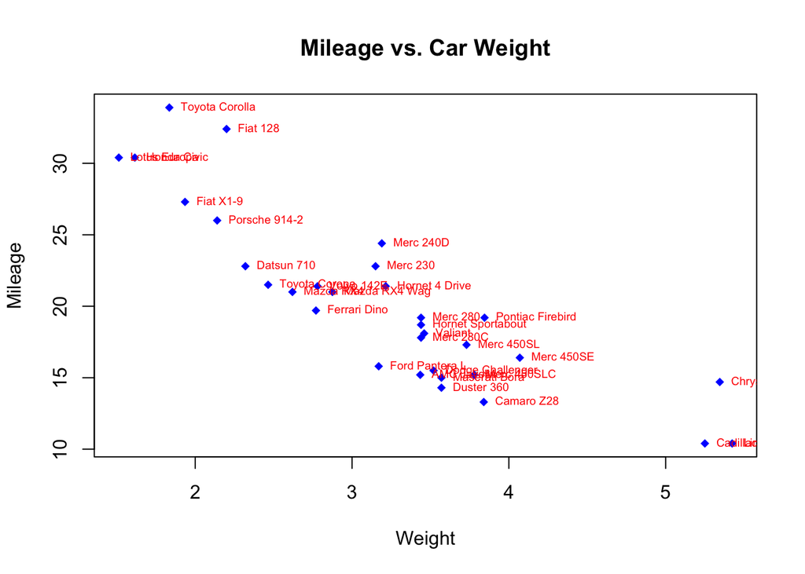

```r
plot(mtcars$wt, mtcars$mpg, main="Mileage vs. Car Weight",
               xlab="Weight",
               ylab="Mileage",
               pch=18, col="blue")


text(mtcars$wt, mtcars$mpg, # Note we cannot use the formula in text
      row.names(mtcars),    # Get the row names
      cex=0.6,              # Scaling of the font size
      pos=4,                # 1=below, 2=left, 3=above, 4=right
      col="red")
```

***

3.0) HERE WE PUT UP LABELS NEXT TO THE POINTS AND PLACE INFORMATION IN THE MARGINS

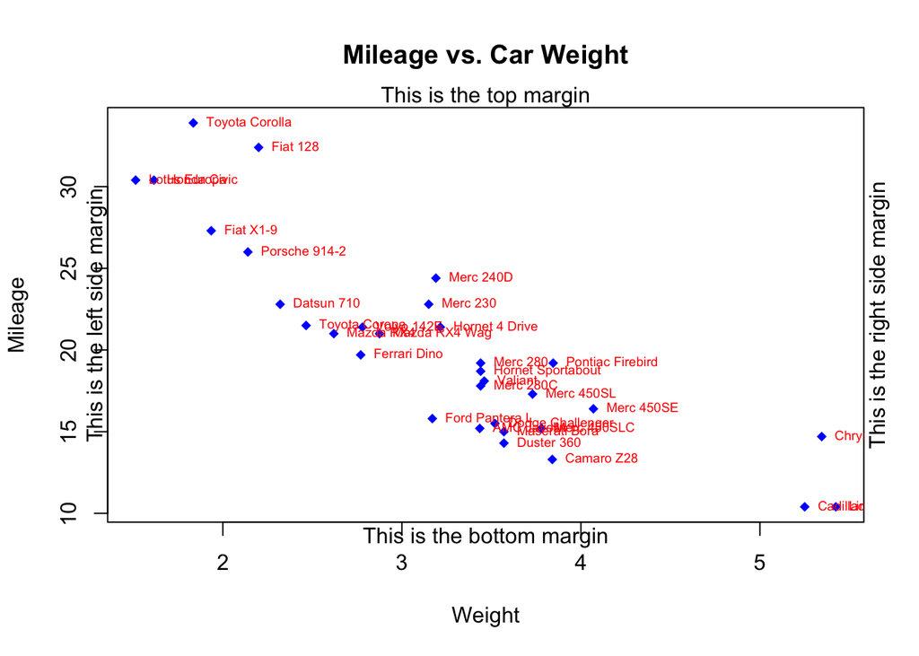

```r
plot(mtcars$wt, mtcars$mpg, main="Mileage vs. Car Weight",
               xlab="Weight",
               ylab="Mileage",
               pch=18, col="blue")


text(mtcars$wt, mtcars$mpg, # Note we cannot use the formula in text
      row.names(mtcars),    # Get the row names
      cex=0.6,              # Scaling of the font size
      pos=4,                # 1=below, 2=left, 3=above, 4=right
      col="red")

mtext("This is the bottom margin",1)

mtext("This is the left side margin",2)

mtext("This is the top margin",3)

mtext("This is the right side margin",4)
```

***

3.0) THIS IS A MORE INVOLVED EXAMPLE THOUGH IS A GOOD ONE TO STUDY AS IT IS REPRESENTATIVE OF “REAL WORLD” GRAPHS

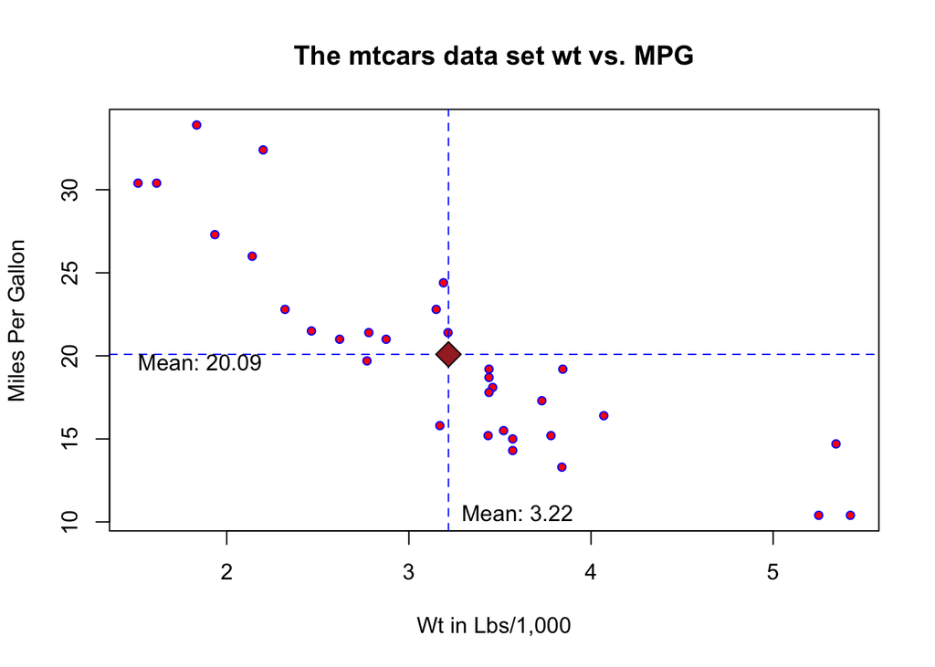

```r
plot(mtcars$mpg ~ mtcars$wt,cex=0.8,
    pch=21,col="blue",bg="red",
    xlab="Wt in Lbs/1,000",
    ylab="Miles Per Gallon")

title(main="The mtcars data set wt vs. MPG")

# Next draw a vertical line at the mean of the weight

abline(v=mean(mtcars$wt),lty=2,col="blue")

# Next draw a horizontal line at the man of the MPG

abline(h=mean(mtcars$mpg),lty=2,col="blue")

points(mean(mtcars$wt),       # Draws a diamond at the common mean
       mean(mtcars$mpg),
       pch=23,col="black",
       bg="brown",
       cex=2)


text(mean(mtcars$wt),min(mtcars$mpg),
     paste("Mean:",round(mean(mtcars$wt),2)),pos=4)

text(min(mtcars$wt),mean(mtcars$mpg),
    paste("Mean:",round(mean(mtcars$mpg),2)),adj=c(0,1))
```

*** ## COLORS

4.0) R HAS SUPPORT FOR COLORS - LOTS OF THEM

```r
length(colors())  # The colors function returns a vector of colors
```

```
## [1] 657
```

```r
colors()[1:5]
```

```
## [1] "white"         "aliceblue"     "antiquewhite"  "antiquewhite1"
## [5] "antiquewhite2"
```

```r
grep("yellow",colors(),value=TRUE)
```

```
##  [1] "greenyellow"          "lightgoldenrodyellow" "lightyellow"
##  [4] "lightyellow1"         "lightyellow2"         "lightyellow3"
##  [7] "lightyellow4"         "yellow"               "yellow1"
## [10] "yellow2"              "yellow3"              "yellow4"
## [13] "yellowgreen"
```

```r
grep("purple",colors(),value=TRUE)
```

```
##  [1] "mediumpurple"  "mediumpurple1" "mediumpurple2" "mediumpurple3"
##  [5] "mediumpurple4" "purple"        "purple1"       "purple2"
##  [9] "purple3"       "purple4"
```

```r
# THERE IS ALSO SUPPORT FOR PREDEFINED COLOR PALETTES

?palette

rainbow(6)  # generate 6 colors from the rainbow palette
```

```
## [1] "#FF0000FF" "#FFFF00FF" "#00FF00FF" "#00FFFFFF" "#0000FFFF" "#FF00FFFF"
```

## BARPLOTS

4.0) BARPLOTS ARE A GREAT WAY TO DISPLAY TABULAR DATA. WE CAN ALSO USE COLORS TO IMPROVE THE GRAPH.

```r
table(mtcars$cyl)
```

```
##
##  4  6  8
## 11  7 14
```

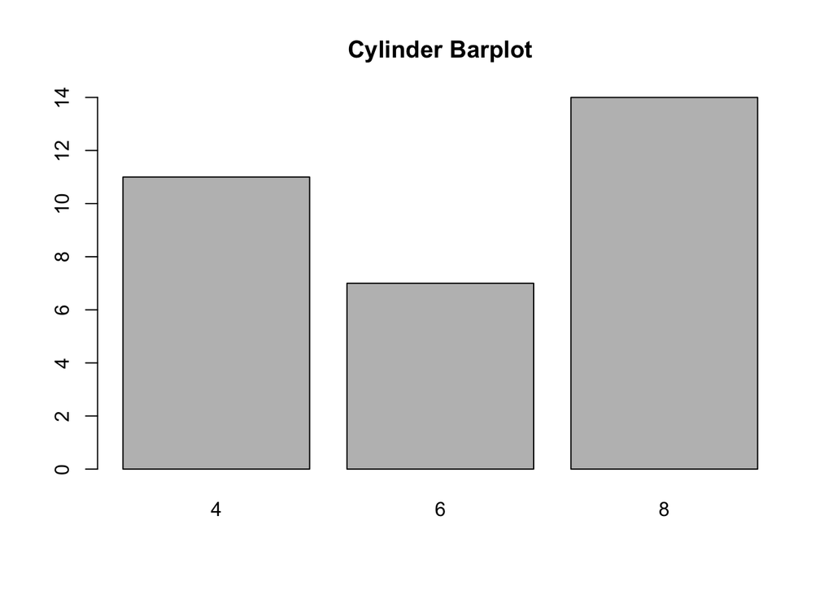

```r
barplot(table(mtcars$cyl), axes=T, main = "Cylinder Barplot")
```

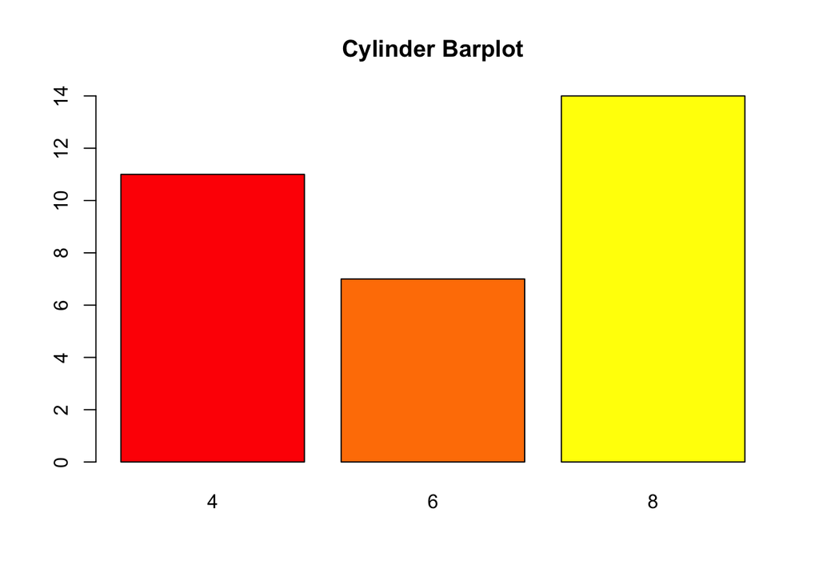

```r
# LETS ADD SOME COLOR TO THE BARPLOT

barplot(table(mtcars$cyl), axes=T,
        main = "Cylinder Barplot", col=heat.colors(3))
```

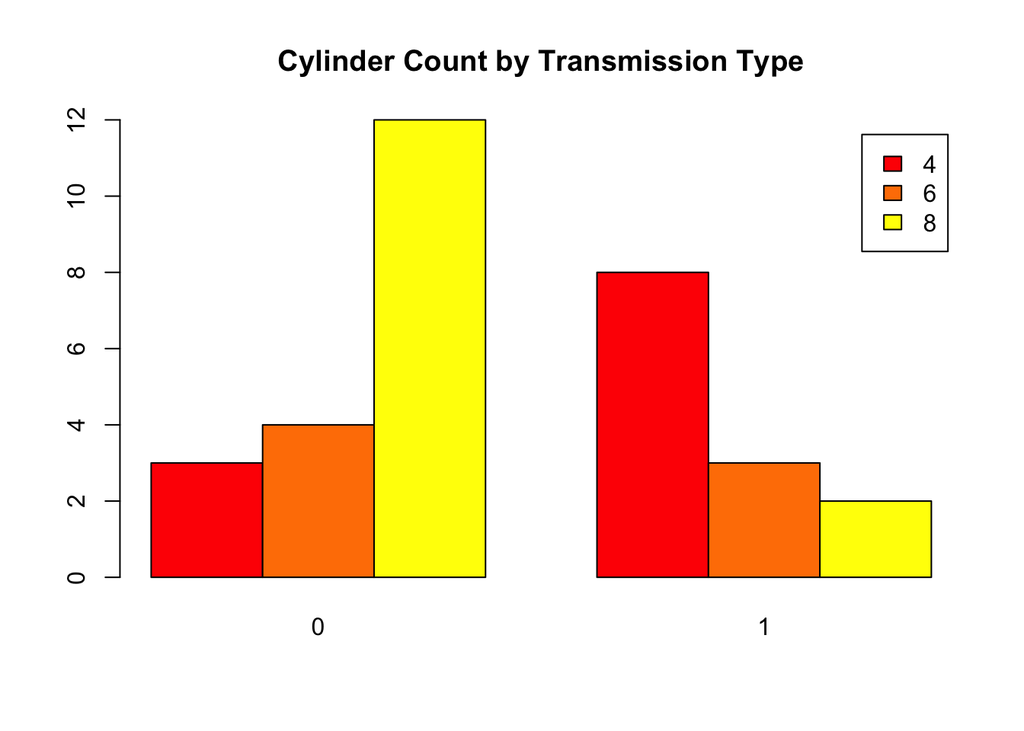

```r
# CREATE A 2 PANEL BAR PLOT

barplot(table(mtcars$cyl,mtcars$am), legend = T, beside = T, col=heat.colors(3), main='Cylinder Count by Transmission Type')
```

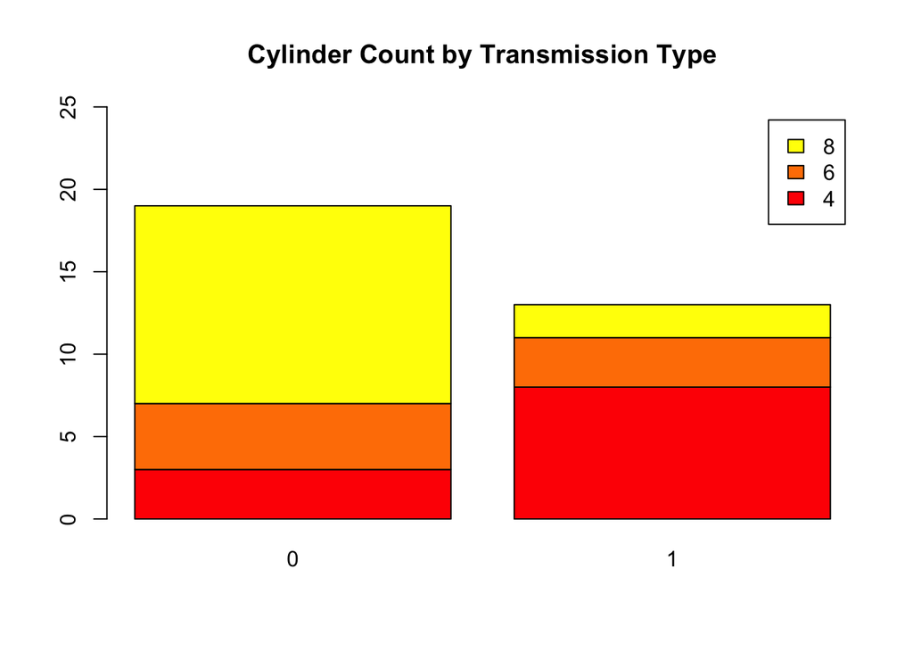

```r
# CREATE A STACKED BAR PLOT

barplot(table(mtcars$cyl,mtcars$am),legend = T,
        beside = F, col=heat.colors(3),
        main='Cylinder Count by Transmission Type',ylim=c(0,25))
```

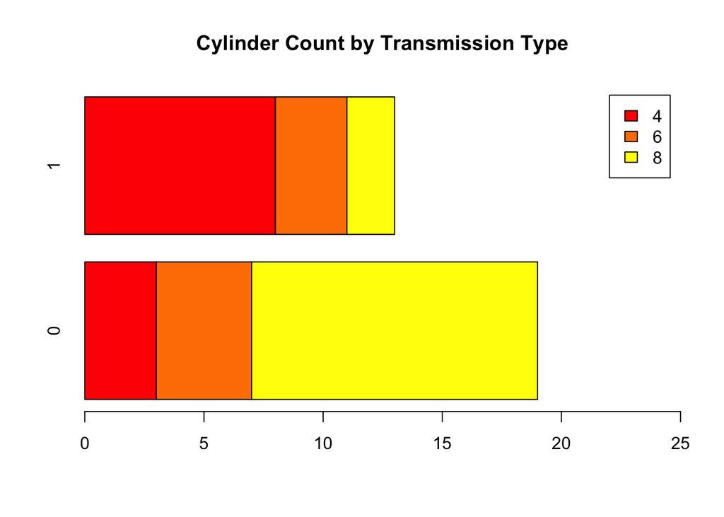

```r
# CREATE A HORIZONTAL BARPLOT

barplot(table(mtcars$cyl,mtcars$am),legend = T,
        beside = F, col=heat.colors(3),
        main='Cylinder Count by Transmission Type',
        xlim=c(0,25),horiz=T)
```

***

PRACTICE 4.1) LET’S GENERATE POINTS USING DIFFERENT COLORS BUT LETS EXPLOIT INFORMATION WITHIN THE DATA FRAME

```r
mycols <- rainbow(2)

mycols
```

```
## [1] "#FF0000FF" "#00FFFFFF"
```

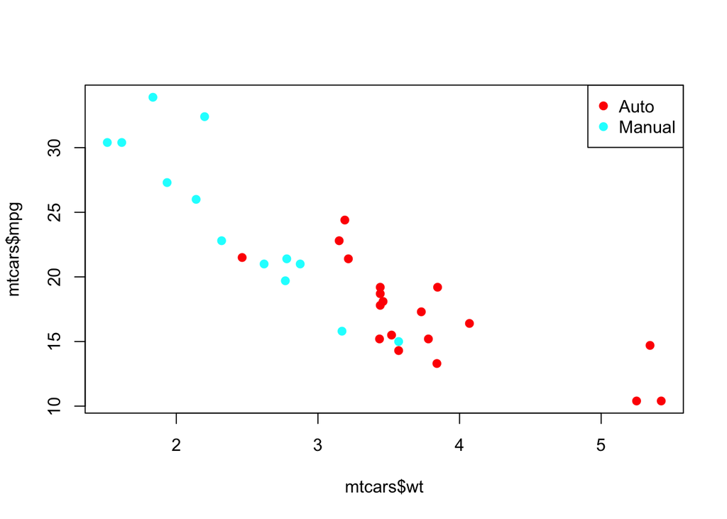

```r
# Remember that the transmission types are indicated by a 0 (auto) or
# 1 (manual). We need to take this into account when indexing into the
# mycols vector. Basically, we add 1 to the transmission since there is
# no element 0 of the mycols vector.

plot(mtcars$wt, mtcars$mpg, col = mycols[mtcars$am+1], pch=19)

legend("topright",c("Auto","Manual"),col=mycols,pch=19)
```

***

PRACTICE 4.2) ADVACNED ANNOTATION EXAMPLE

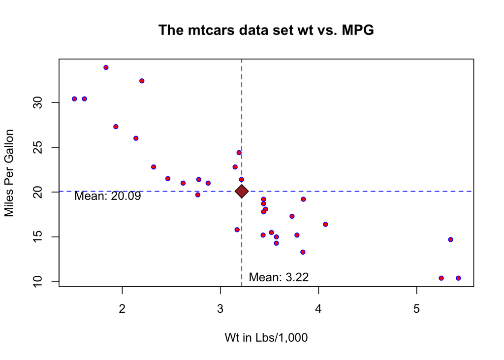

```r
plot(mtcars$mpg ~ mtcars$wt,cex=0.8,
    pch=21,col="blue",bg="red",
    xlab="Wt in Lbs/1,000",
    ylab="Miles Per Gallon")

title(main="The mtcars data set wt vs. MPG")

# Next draw a vertical line at the mean of the weight

abline(v=mean(mtcars$wt),lty=2,col="blue")

# Next draw a horizontal line at the man of the MPG

abline(h=mean(mtcars$mpg),lty=2,col="blue")

points(mean(mtcars$wt),       # Draws a diamond at the common mean
       mean(mtcars$mpg),
       pch=23,col="black",
       bg="brown",
       cex=2)

text(mean(mtcars$wt),min(mtcars$mpg),
     paste("Mean:",round(mean(mtcars$wt),2)),pos=4)

text(min(mtcars$wt),mean(mtcars$mpg),
    paste("Mean:",round(mean(mtcars$mpg),2)),adj=c(0,1))
```

***

PRACTICE 4.3) CUSTOM AXIS EXAMPLE

```r
url  <- "http://steviep42.bitbucket.org/bios545r/SUPP.DIR/stock.data.14.csv"

msft <- read.csv(url)

head(msft)
```

```
##         Date  Open  High   Low Close   Volume Adj.Close
## 1 2014-01-02 37.35 37.40 37.10 37.16 30632200     36.17
## 2 2014-01-03 37.20 37.22 36.60 36.91 31134800     35.93
## 3 2014-01-06 36.85 36.89 36.11 36.13 43603700     35.17
## 4 2014-01-07 36.33 36.49 36.21 36.41 35802800     35.44
## 5 2014-01-08 36.00 36.14 35.58 35.76 59971700     34.81
## 6 2014-01-09 35.88 35.91 35.40 35.53 36516300     34.58
```

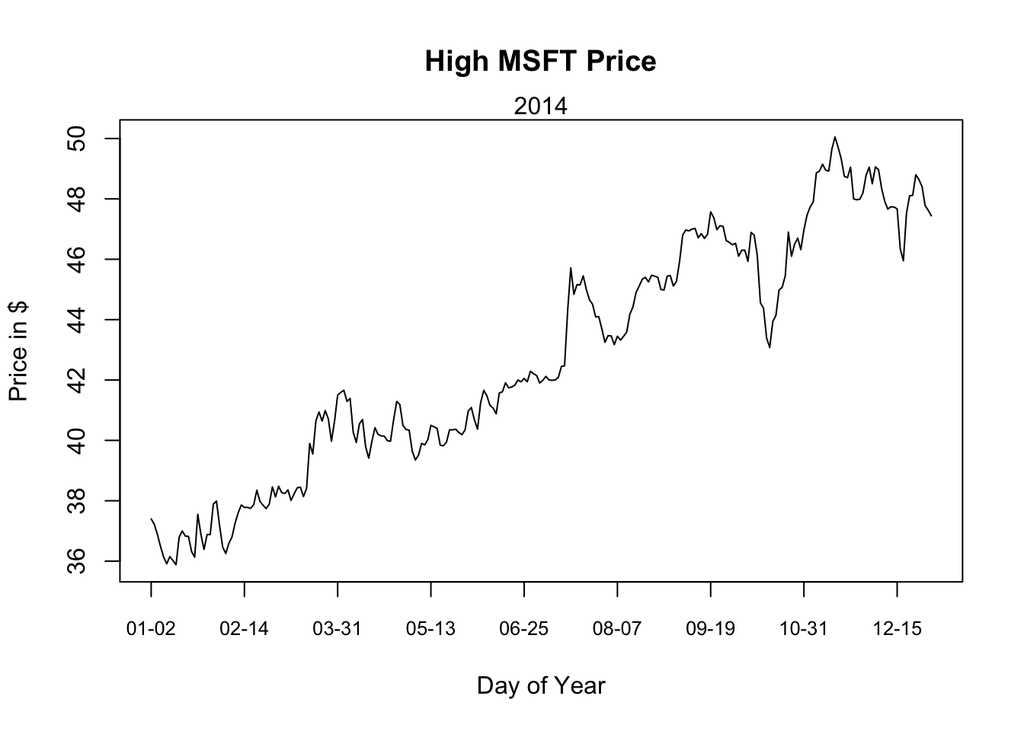

```r
plot(msft$High,type="l",main="High MSFT Price",
     xlab="Day of Year",ylab="Price in $", xaxt="n")

mtext("2014",3)

dseq <- seq(1,nrow(msft),30)

axislabs <- substr(msft$Date[dseq],6,10)

axis(1, at=dseq, labels=axislabs, cex.axis=0.8)
```

***

PRACTICE 5.0) ANIMATION OF CENTRAL LIMIT THEOREM

```r
myhist <- function(pop,timestosamp, numtosamp, sleep=0.25) {

  avgvec <- vector()
  length(avgvec) <- timestosamp

  for (ii in 1:timestosamp) {
    avgvec <- c(avgvec,mean(sample(pop,numtosamp)))
    hist(avgvec,main=paste("Histogram - Iteration #",ii,sep=" "),
         xlim=c(-3,3))
    Sys.sleep(sleep)
  }
}

# myhist(x,500,5,sleep=.10)
```

PRACTICE 5.0) REPRODUCTION OF NEWSPAPER GRAPHIC

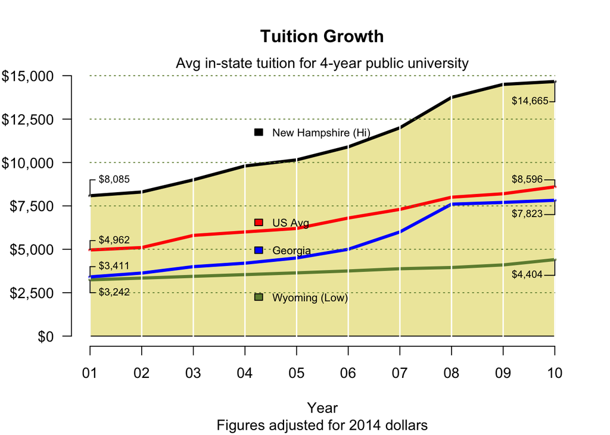

```r
# Reproduction of a consumer level graphic publication found in the
# Atlanta Journal Constitution.
# Steve Pittard wsp@emory.edu

# Tuition Data Set - Approximate values

Wyoming <- c(3242,3342,3442,3542,3642,3752,3880,3950,4100,4404)
Georgia <- c(3411,3630,4000,4200,4500,5000,6000,7600,7700,7823)
USAver  <- c(4962,5100,5800,6000,6200,6800,7300,8000,8200,8596)
NewHamp <- c(8085,8300,9000,9800,10150,10900,12000,13750,14500,14665)

tuition <- data.frame(rbind(Wyoming,Georgia,USAver,NewHamp))
ylims <- c(0,max(tuition[,10]))

plot(1:10,tuition[1,],type="n",lwd=2,col="green",
     ylab="",ylim=ylims,yaxt="n",bty="n",xaxt="n",
     xlab="Year",main="Tuition Growth",sub="Figures adjusted for 2014 dollars")
mcols <- c("#6E8B3D","blue","red","black")
polygon(c(1,1:10,10),c(0,tuition[4,],0),col="#EEE8AA")

points(1:10,tuition[1,],type="l",lwd=3.5,col="#6E8B3D")
points(1:10,tuition[2,],type="l",lwd=3.5,col="blue")
points(1:10,tuition[3,],type="l",lwd=3.5,col="red")
points(1:10,tuition[4,],type="l",lwd=3.5,col="black")

abline(v=1:10,col="white",lwd=1.5)
segments(1,seq(2500,15000,by=2500),10,seq(2500,15000,by=2500),lty=3,col="#6E8B3D")
xlabs <- c(paste(0,1:9,sep=""),"10")
axis(1,at=1:10,labels=xlabs)
ylabs <- formatC(seq(0,15000,2500),format="d",big.mark=",")
ylabs <- paste("$",ylabs,sep="")
axis(2,at=seq(0,15000,2500),ylabs,las=1)
mtext("Avg in-state tuition for 4-year public university",side=3)

legend(04,3000,c("Wyoming (Low)"),fill=c("#6E8B3D"),bty="n",cex=0.75)
legend(04,5700,c("Georgia"),fill=c("blue"),bty="n",cex=0.75)
legend(04,7300,c("US Avg"),fill=c("red"),bty="n",cex=0.75)
legend(04,12500,c("New Hampshire (Hi)"),fill=c("black"),bty="n",cex=0.75)

text(1,c(2500,4000,5500,9000),
     paste("$",formatC(tuition[1:4,1],format="d",big.mark=","),sep=""),pos=4,cex=0.7)

segments(1,c(2500,4000,5500,9000),1.1,c(2500,4000,5500,9000))
segments(1,2500,1,tuition[1,1])
segments(1,tuition[2:4,1],1,c(4000,5500,9000))


text(9,c(3500,7000,9000,13500),
     paste("$",formatC(tuition[1:4,10],format="d",big.mark=","),sep=""),pos=4,cex=0.7)

# This could be cleaned up using some programming approaches

segments(9.8,3500,10,3500)
segments(10,3500,10,tuition[1,10])

segments(9.8,7000,10,7000)
segments(10,7000,10,tuition[2,10])

segments(10,tuition[3,10],10,9000)
segments(10,9000,9.8,9000)

segments(9.9,13500,10,13500)
segments(10,13500,10,tuition[4,10])
```

***